# Observer analyses

Hannah, 5/16/2017

Data for Study 1 was collected in Fall 2015. Data for Study 2 was collected in Fall 2016 (hypotheses were preregistered at aspredicted.org).

**In Study 1:**  
- 101 subjects participated  
- 8 subjects’ AP data was discarded (see “Study1_badsubsAP.txt”)  
- 9 subjects’ WIT data was discarded (see “Study1_badsubsWIT.txt”)  
*This left 93 subjects with AP data and 92 subjects with WIT data.*

Additionally, IMS/EMS data is missing for subs 3, 27, 53, 82, 88, 89, 90, and 101.

**In Study 2:**  
- 206 subjects participated  
- 8 subjects’ AP data was discarded (see “Study2_badsubsAP.txt”)  
- 7 subjects’ WIT data was discarded (see “Study2_badsubsWIT.txt”)  
*This left 198 subjects with AP data and 199 subjects with WIT data.*

Additionally, IMS/EMS data is missing for 111, 189, and 201.

There were 48 trials for each condition in each task. In Study 2, each task was split into two sections so that participants could answer anxiety questions in the middle and end of each task.

### 1. Accuracy in each task:

#### 2 (Prime: Black/White) x 2 (Target: gun/tool or positive/negative) rANOVA

Only showing interaction indicating racial bias (Prime x Target). For calculation of effect sizes, see “7 Effect sizes.R”  
#### Study 1:  
**WIT**

```
##                      Df Sum Sq Mean Sq F value   Pr(>F)
## PrimeType:TargetType  1   2883  2882.9    96.5 5.97e-16 ***
## Residuals            91   2719    29.9
## ---
## Signif. codes:  0 '***' 0.001 '**' 0.01 '*' 0.05 '.' 0.1 ' ' 1
```

**AP**

```
##                               Df Sum Sq Mean Sq F value Pr(>F)
## PrimeType:TargetType           1   1794  1794.3  39.797  1e-08 ***
## PrimeType:TargetType:Observer  1     43    42.5   0.943  0.334
## Residuals                     91   4103    45.1
## ---
## Signif. codes:  0 '***' 0.001 '**' 0.01 '*' 0.05 '.' 0.1 ' ' 1
```

#### Study 2:

Only showing interaction indicating racial bias (Prime x Target). For calculation of effect sizes, see “7 Effect sizes.R”  
**WIT**

```
##                       Df Sum Sq Mean Sq F value Pr(>F)
## PrimeType:TargetType   1   3861    3861   120.7 <2e-16 ***
## Residuals            198   6331      32
## ---
## Signif. codes:  0 '***' 0.001 '**' 0.01 '*' 0.05 '.' 0.1 ' ' 1
```

**AP**

```
##                       Df Sum Sq Mean Sq F value   Pr(>F)
## PrimeType:TargetType   1   2478  2478.3   54.86 3.71e-12 ***
## Residuals            197   8900    45.2
## ---
## Signif. codes:  0 '***' 0.001 '**' 0.01 '*' 0.05 '.' 0.1 ' ' 1
```

### 2. Comparing accuracy across tasks

##### - Correlation between performance bias scores

##### - Look at 3 way Prime x Target x Task interaction

#### Study 1

Excludes subjects that don’t have data in both tasks (only includes sample of 90).

#### A. Correlation between performance bias scores on each task

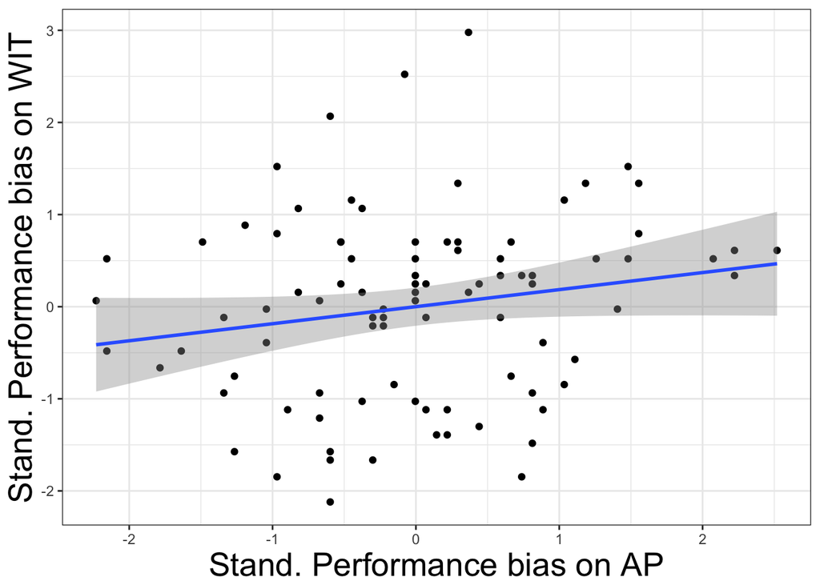

```
##
## Call:
## lm(formula = APStand ~ WITStand, data = s1.perfBias)
##
## Residuals:
##      Min       1Q   Median       3Q      Max
## -2.25273 -0.64697 -0.04138  0.68037  2.40625
##
## Coefficients:
##               Estimate Std. Error t value Pr(>|t|)
## (Intercept) -9.621e-17  1.042e-01   0.000   1.0000
## WITStand     1.851e-01  1.048e-01   1.767   0.0807 .
## ---
## Signif. codes:  0 '***' 0.001 '**' 0.01 '*' 0.05 '.' 0.1 ' ' 1
##
## Residual standard error: 0.9883 on 88 degrees of freedom
## Multiple R-squared:  0.03427,    Adjusted R-squared:  0.02329
## F-statistic: 3.123 on 1 and 88 DF,  p-value: 0.08068
```

#### B. Examine 3 way Prime x Target x Task interaction

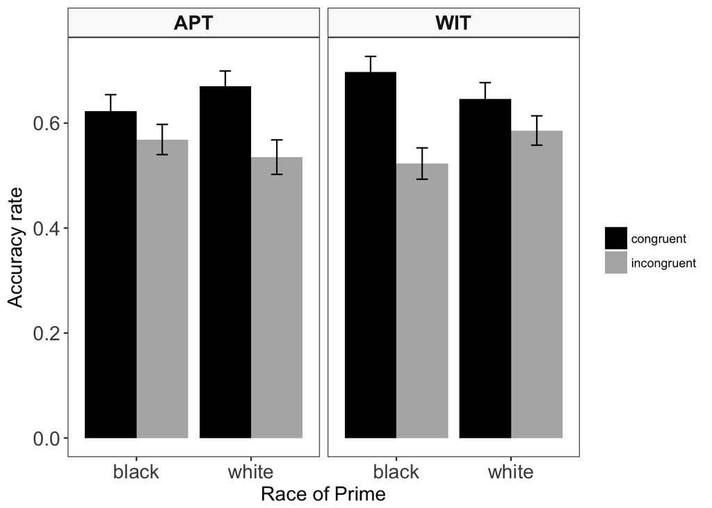

```
##                        Df Sum Sq Mean Sq F value   Pr(>F)
## PrimeType:ConType:Task  1    992   991.7   23.04 6.35e-06 ***
## Residuals              89   3830    43.0
## ---
## Signif. codes:  0 '***' 0.001 '**' 0.01 '*' 0.05 '.' 0.1 ' ' 1
```

#### A. Correlation between performance bias scores on each task

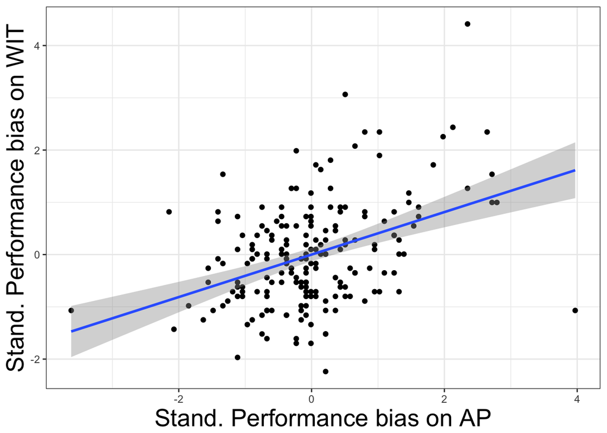

```
##
## Call:
## lm(formula = APStand ~ WITStand, data = s2.perfBias)
##
## Residuals:
##     Min      1Q  Median      3Q     Max
## -3.1856 -0.6008 -0.0491  0.5380  4.4047
##
## Coefficients:
##              Estimate Std. Error t value Pr(>|t|)
## (Intercept) 3.394e-16  6.594e-02   0.000        1
## WITStand    4.065e-01  6.611e-02   6.149 4.46e-09 ***
## ---
## Signif. codes:  0 '***' 0.001 '**' 0.01 '*' 0.05 '.' 0.1 ' ' 1
##
## Residual standard error: 0.916 on 191 degrees of freedom
## Multiple R-squared:  0.1653, Adjusted R-squared:  0.1609
## F-statistic: 37.82 on 1 and 191 DF,  p-value: 4.456e-09
```

#### B. Examine 3 way Prime x Target x Task interaction

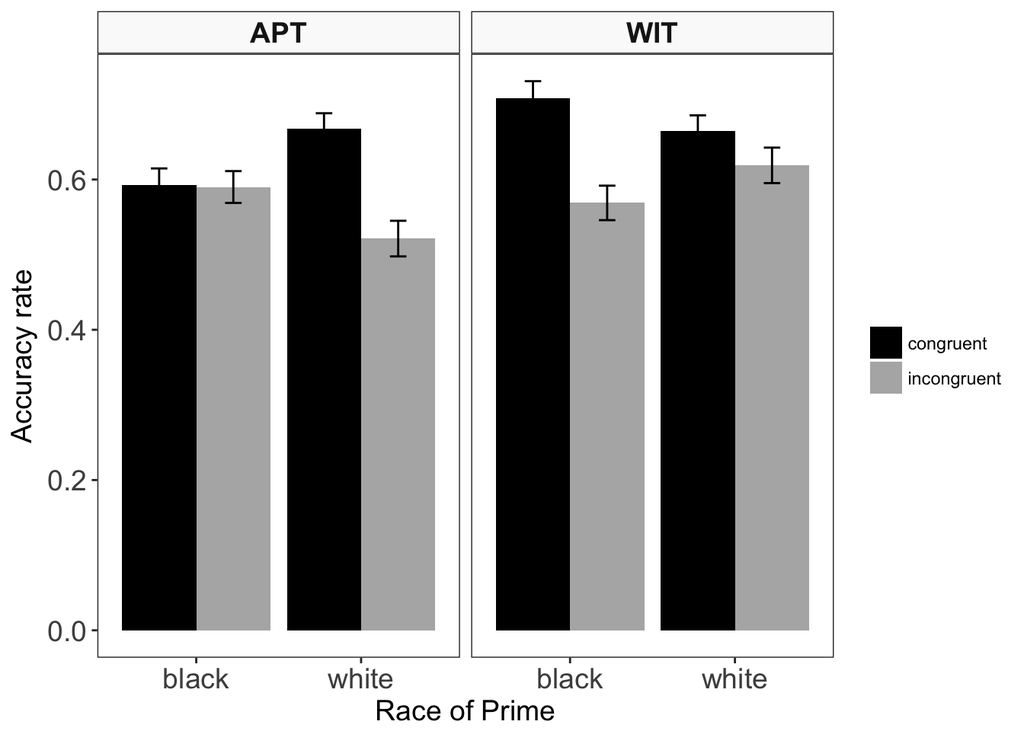

```
##                         Df Sum Sq Mean Sq F value Pr(>F)
## PrimeType:ConType:Task   1   3123  3123.3   94.02 <2e-16 ***
## Residuals              192   6378    33.2
## ---
## Signif. codes:  0 '***' 0.001 '**' 0.01 '*' 0.05 '.' 0.1 ' ' 1
```

### 3. Look at correlations between PDP estimates

#### Study 1:

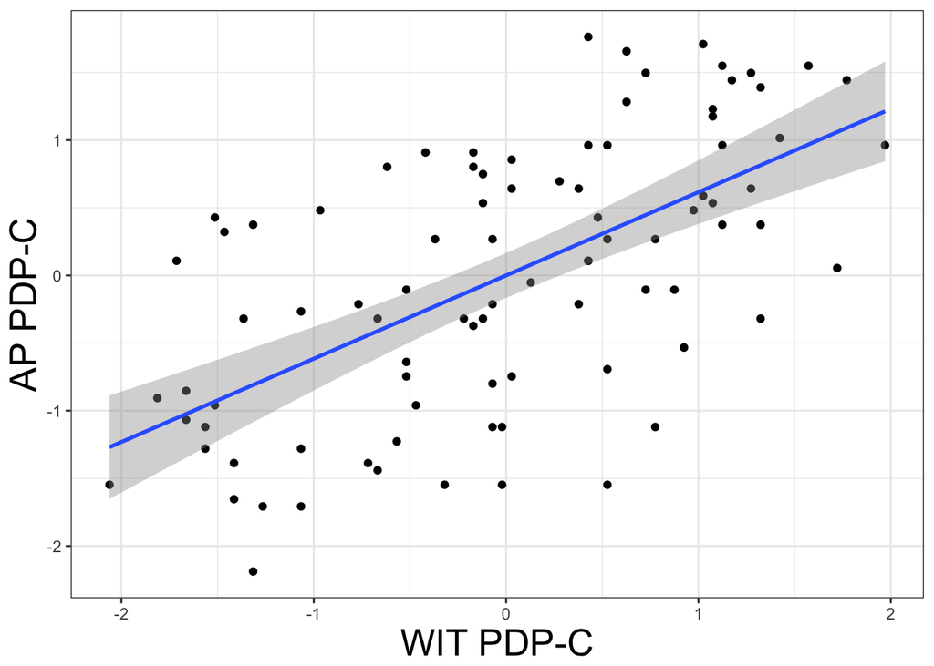

```
##
## Call:
## lm(formula = WIT_MeanC.stand ~ AP_MeanC.stand, data = s1.widePDP)
##
## Residuals:
##      Min       1Q   Median       3Q      Max
## -1.77991 -0.52543  0.04554  0.59056  1.68756
##
## Coefficients:
##                 Estimate Std. Error t value Pr(>|t|)
## (Intercept)    4.088e-16  8.353e-02   0.000        1
## AP_MeanC.stand 6.157e-01  8.400e-02   7.329 1.06e-10 ***
## ---
## Signif. codes:  0 '***' 0.001 '**' 0.01 '*' 0.05 '.' 0.1 ' ' 1
##
## Residual standard error: 0.7925 on 88 degrees of freedom
## Multiple R-squared:  0.379,  Adjusted R-squared:  0.372
## F-statistic: 53.72 on 1 and 88 DF,  p-value: 1.062e-10
```

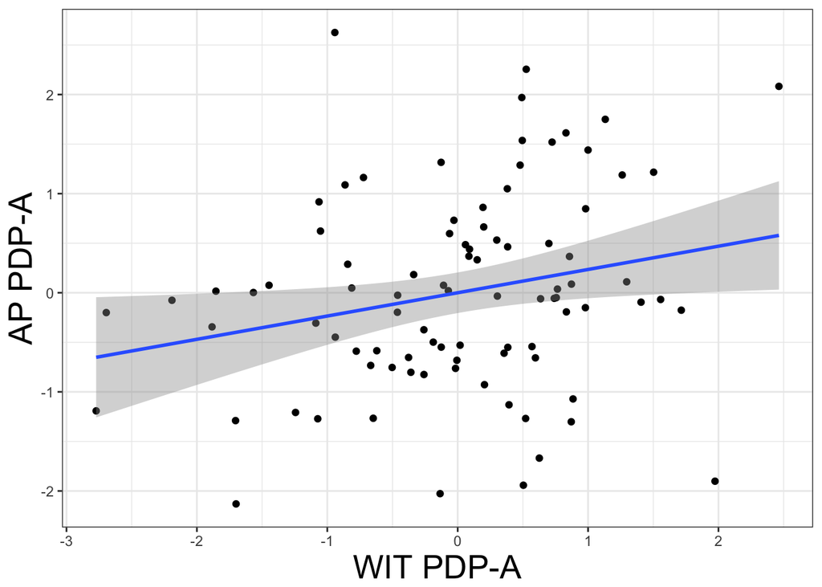

```
##
## Call:
## lm(formula = WIT_AResid.stand ~ AP_AResid.stand, data = s1.widePDP)
##
## Residuals:
##      Min       1Q   Median       3Q      Max
## -2.64807 -0.47586  0.03648  0.71495  2.42030
##
## Coefficients:
##                   Estimate Std. Error t value Pr(>|t|)
## (Intercept)     -9.771e-17  1.030e-01   0.000   1.0000
## AP_AResid.stand  2.349e-01  1.036e-01   2.267   0.0258 *
## ---
## Signif. codes:  0 '***' 0.001 '**' 0.01 '*' 0.05 '.' 0.1 ' ' 1
##
## Residual standard error: 0.9775 on 88 degrees of freedom
## Multiple R-squared:  0.05519,    Adjusted R-squared:  0.04445
## F-statistic:  5.14 on 1 and 88 DF,  p-value: 0.02583
```

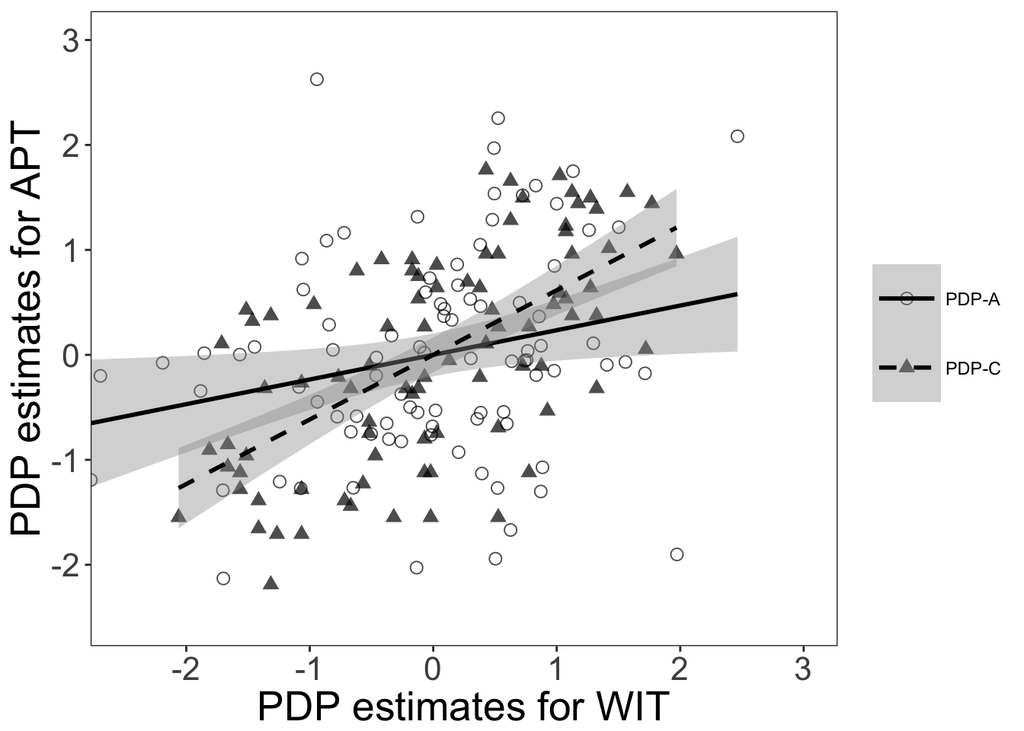

```
##
## Call:
## lm(formula = WITestimate ~ APTestimate * Type, data = compareAC)
##
## Residuals:
##      Min       1Q   Median       3Q      Max
## -2.64807 -0.49558  0.03792  0.65228  2.42030
##
## Coefficients:
##                         Estimate Std. Error t value Pr(>|t|)
## (Intercept)           -1.629e-16  9.380e-02   0.000  1.00000
## APTestimate            2.349e-01  9.432e-02   2.491  0.01368 *
## TypePDP-C              5.879e-16  1.326e-01   0.000  1.00000
## APTestimate:TypePDP-C  3.807e-01  1.334e-01   2.854  0.00483 **
## ---
## Signif. codes:  0 '***' 0.001 '**' 0.01 '*' 0.05 '.' 0.1 ' ' 1
##
## Residual standard error: 0.8898 on 176 degrees of freedom
## Multiple R-squared:  0.2171, Adjusted R-squared:  0.2038
## F-statistic: 16.27 on 3 and 176 DF,  p-value: 2.233e-09
```

#### Study 2:

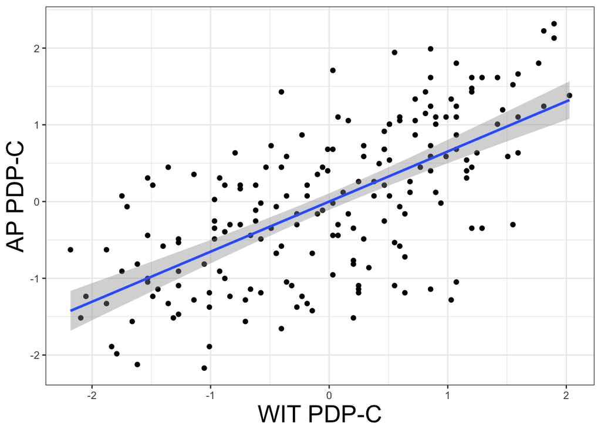

```
##
## Call:
## lm(formula = WIT_MeanC.stand ~ AP_MeanC.stand, data = s2.widePDP)
##
## Residuals:
##      Min       1Q   Median       3Q      Max
## -1.79597 -0.54572  0.03667  0.51197  1.86599
##
## Coefficients:
##                  Estimate Std. Error t value Pr(>|t|)
## (Intercept)    -1.645e-16  5.468e-02    0.00        1
## AP_MeanC.stand  6.527e-01  5.482e-02   11.91   <2e-16 ***
## ---
## Signif. codes:  0 '***' 0.001 '**' 0.01 '*' 0.05 '.' 0.1 ' ' 1
##
## Residual standard error: 0.7596 on 191 degrees of freedom
## Multiple R-squared:  0.426,  Adjusted R-squared:  0.423
## F-statistic: 141.7 on 1 and 191 DF,  p-value: < 2.2e-16
```

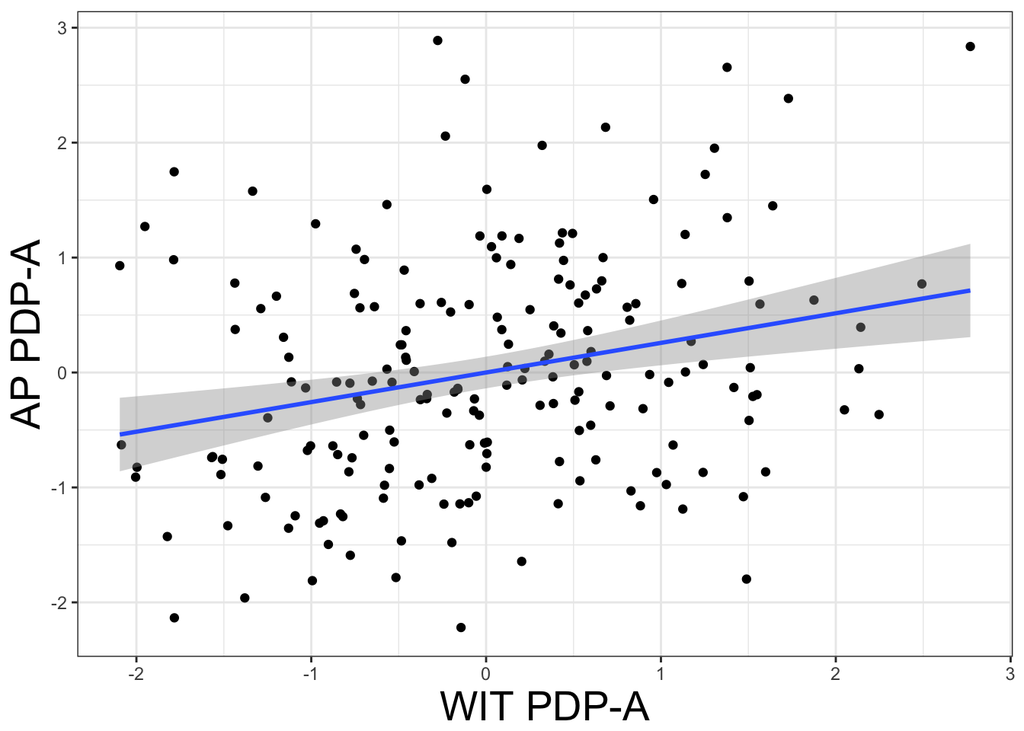

```
##
## Call:
## lm(formula = WIT_AResid.stand ~ AP_AResid.stand, data = s2.widePDP)
##
## Residuals:
##     Min      1Q  Median      3Q     Max
## -2.3346 -0.6315 -0.0074  0.6270  2.3417
##
## Coefficients:
##                  Estimate Std. Error t value Pr(>|t|)
## (Intercept)     1.869e-17  6.973e-02   0.000 1.000000
## AP_AResid.stand 2.577e-01  6.991e-02   3.685 0.000298 ***
## ---
## Signif. codes:  0 '***' 0.001 '**' 0.01 '*' 0.05 '.' 0.1 ' ' 1
##
## Residual standard error: 0.9688 on 191 degrees of freedom
## Multiple R-squared:  0.06639,    Adjusted R-squared:  0.0615
## F-statistic: 13.58 on 1 and 191 DF,  p-value: 0.0002975
```

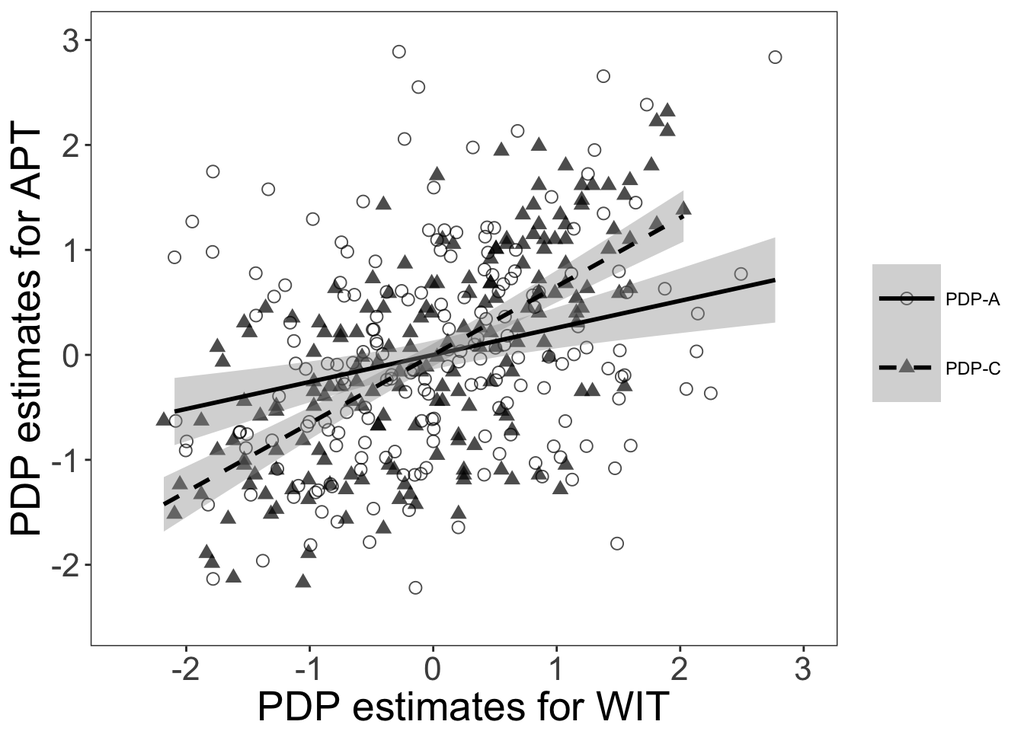

```
##
## Call:
## lm(formula = WITestimate ~ APTestimate * Type, data = compareAC)
##
## Residuals:
##      Min       1Q   Median       3Q      Max
## -2.33459 -0.57549  0.01939  0.57615  2.34165
##
## Coefficients:
##                         Estimate Std. Error t value Pr(>|t|)
## (Intercept)            8.660e-17  6.266e-02   0.000        1
## APTestimate            2.577e-01  6.282e-02   4.101 5.02e-05 ***
## TypePDP-C             -2.384e-16  8.861e-02   0.000        1
## APTestimate:TypePDP-C  3.950e-01  8.884e-02   4.446 1.15e-05 ***
## ---
## Signif. codes:  0 '***' 0.001 '**' 0.01 '*' 0.05 '.' 0.1 ' ' 1
##
## Residual standard error: 0.8705 on 382 degrees of freedom
## Multiple R-squared:  0.2462, Adjusted R-squared:  0.2403
## F-statistic: 41.59 on 3 and 382 DF,  p-value: < 2.2e-16
```

### 4. Make composite for anxiety in Study 2

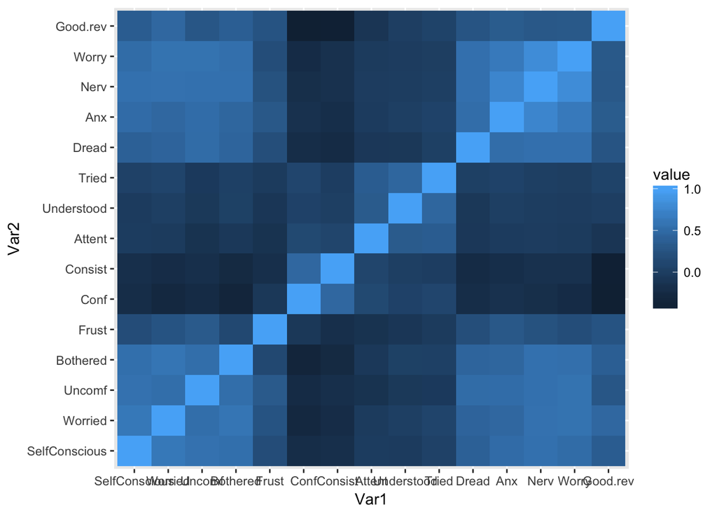

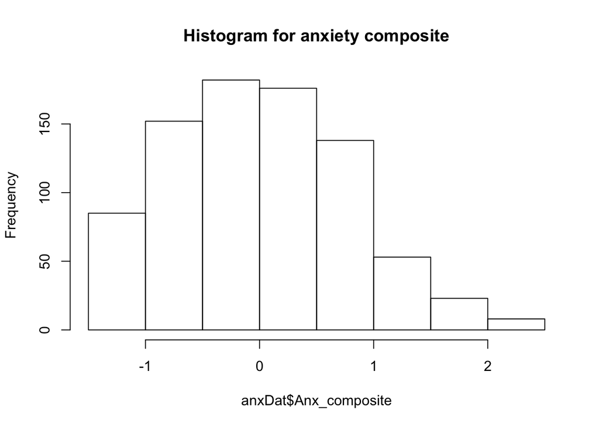

Composite is composed of 8 items (standardized before averaged together), alpha = .91

Look at correlation between first and second blocks:

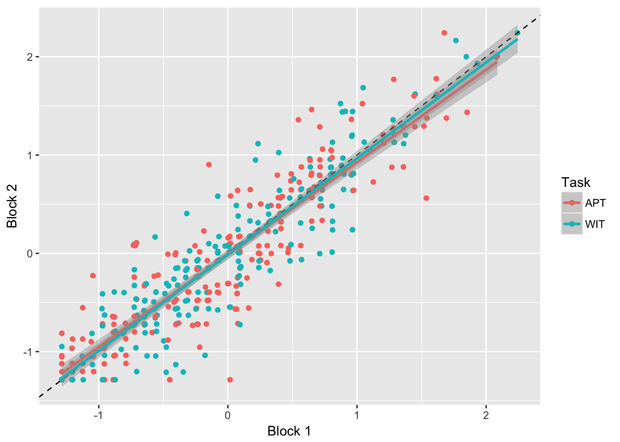

The correlation between the anxiety composite score on the first block and the second block is 0.9098042.

### 5. Effect of observer on response accuracy bias, PDP-A, PDP-C, anxiety

#### Study 1:

**Perf bias:**

```
##
## Error: Subject
##           Df Sum Sq  Mean Sq F value Pr(>F)
## Observer   1 0.0007 0.000738   0.038  0.846
## Residuals 88 1.7231 0.019581
##
## Error: Subject:Task
##               Df Sum Sq Mean Sq F value Pr(>F)
## Task           1 0.0244 0.02435   1.849  0.177
## Observer:Task  1 0.0356 0.03560   2.703  0.104
## Residuals     88 1.1591 0.01317
```

```
##            Effect PartialEtaSquared
## 1        Observer             0.000
## 2            Task             0.021
## 3 Observer x Task             0.030
```

**PDP-C estimates:**

```
##
## Error: Subject
##           Df Sum Sq Mean Sq F value Pr(>F)
## Observer   1  0.013 0.01285   0.193  0.662
## Residuals 88  5.866 0.06666
##
## Error: Subject:Task
##               Df Sum Sq  Mean Sq F value Pr(>F)
## Task           1 0.0010 0.000965   0.061  0.806
## Observer:Task  1 0.0102 0.010188   0.643  0.425
## Residuals     88 1.3951 0.015853
```

```
##            Effect PartialEtaSquared
## 1        Observer             0.002
## 2            Task             0.001
## 3 Observer x Task             0.007
```

**PDP-A estimates:**

```
##
## Error: Subject
##           Df Sum Sq Mean Sq F value Pr(>F)
## Observer   1 0.0109 0.01090   0.371  0.544
## Residuals 88 2.5838 0.02936
##
## Error: Subject:Task
##               Df Sum Sq  Mean Sq F value Pr(>F)
## Task           1 0.0007 0.000695   0.038  0.845
## Observer:Task  1 0.0278 0.027781   1.535  0.219
## Residuals     88 1.5929 0.018102
```

```
##            Effect PartialEtaSquared
## 1        Observer             0.004
## 2            Task             0.000
## 3 Observer x Task             0.017
```

**Error-related distress:**

```
##
## Error: Subject
##           Df Sum Sq Mean Sq F value Pr(>F)
## Observer   1   0.06  0.0617   0.024  0.877
## Residuals 88 224.45  2.5506
##
## Error: Subject:Task
##               Df Sum Sq Mean Sq F value Pr(>F)
## Task           1   0.00  0.0025   0.005  0.943
## Observer:Task  1   0.02  0.0222   0.046  0.830
## Residuals     88  42.42  0.4820
```

```
##            Effect PartialEtaSquared
## 1        Observer                 0
## 2            Task                 0
## 3 Observer x Task                 0
```

#### Study 2:

**Perf bias:**

```
##
## Error: Subject
##            Df Sum Sq  Mean Sq F value Pr(>F)
## Observer    1  0.005 0.005071   0.216  0.643
## Residuals 191  4.481 0.023462
##
## Error: Subject:Task
##                Df Sum Sq Mean Sq F value Pr(>F)
## Task            1 0.0329 0.03288   3.326 0.0697 .
## Observer:Task   1 0.0410 0.04099   4.147 0.0431 *
## Residuals     191 1.8879 0.00988
## ---
## Signif. codes:  0 '***' 0.001 '**' 0.01 '*' 0.05 '.' 0.1 ' ' 1
```

```
##            Effect PartialEtaSquared
## 1        Observer             0.001
## 2            Task             0.017
## 3 Observer x Task             0.021
```

**PDP-C estimates:**

```
##
## Error: Subject
##            Df Sum Sq Mean Sq F value Pr(>F)
## Observer    1  0.044 0.04436     0.5   0.48
## Residuals 191 16.957 0.08878
##
## Error: Subject:Task
##                Df Sum Sq Mean Sq F value   Pr(>F)
## Task            1  0.492  0.4920  26.185 7.53e-07 ***
## Observer:Task   1  0.007  0.0066   0.351    0.554
## Residuals     191  3.589  0.0188
## ---
## Signif. codes:  0 '***' 0.001 '**' 0.01 '*' 0.05 '.' 0.1 ' ' 1
```

```
##            Effect PartialEtaSquared
## 1        Observer             0.003
## 2            Task             0.121
## 3 Observer x Task             0.002
```

**PDP-A estimates:**

```
##
## Error: Subject
##            Df Sum Sq Mean Sq F value Pr(>F)
## Observer    1  0.047 0.04684   1.541  0.216
## Residuals 191  5.804 0.03039
##
## Error: Subject:Task
##                Df Sum Sq  Mean Sq F value Pr(>F)
## Task            1  0.000 0.000288   0.016  0.900
## Observer:Task   1  0.003 0.002897   0.159  0.691
## Residuals     191  3.480 0.018217
```

```
##            Effect PartialEtaSquared
## 1        Observer             0.008
## 2            Task             0.000
## 3 Observer x Task             0.001
```

**Anxiety composite:**

```
##
## Error: Subject
##            Df Sum Sq Mean Sq F value Pr(>F)
## Observer    1   0.04  0.0392   0.037  0.849
## Residuals 191 204.96  1.0731
##
## Error: Subject:Task
##                Df Sum Sq Mean Sq F value Pr(>F)
## Task            1  0.258 0.25769   2.873 0.0917 .
## Observer:Task   1  0.025 0.02474   0.276 0.6001
## Residuals     191 17.130 0.08968
## ---
## Signif. codes:  0 '***' 0.001 '**' 0.01 '*' 0.05 '.' 0.1 ' ' 1
```

```
##            Effect PartialEtaSquared
## 1        Observer             0.000
## 2            Task             0.015
## 3 Observer x Task             0.001
```

**Moderation of observer effect by anxiety:** Uses a multiple regression because of continuous nature of anxiety.

```
##
## Call:
## lm(formula = perfBias ~ Observer * Anx_composite, data = s2.wide)
##
## Residuals:
##      Min       1Q   Median       3Q      Max
## -0.49176 -0.08266 -0.00914  0.06813  0.58119
##
## Coefficients:
##                               Estimate Std. Error t value Pr(>|t|)
## (Intercept)                    0.08019    0.00901   8.899   <2e-16 ***
## ObserverPresent                0.00660    0.01298   0.508   0.6114
## Anx_composite                  0.02019    0.01185   1.704   0.0892 .
## ObserverPresent:Anx_composite  0.02245    0.01710   1.313   0.1901
## ---
## Signif. codes:  0 '***' 0.001 '**' 0.01 '*' 0.05 '.' 0.1 ' ' 1
##
## Residual standard error: 0.1274 on 382 degrees of freedom
## Multiple R-squared:  0.0382, Adjusted R-squared:  0.03065
## F-statistic: 5.057 on 3 and 382 DF,  p-value: 0.001906
```

```
##
## Call:
## lm(formula = MeanC ~ Observer * Anx_composite, data = s2.wide)
##
## Residuals:
##     Min      1Q  Median      3Q     Max
## -0.5280 -0.1702  0.0134  0.1813  0.4705
##
## Coefficients:
##                               Estimate Std. Error t value Pr(>|t|)
## (Intercept)                    0.36266    0.01624  22.330  < 2e-16 ***
## ObserverPresent                0.02275    0.02340   0.972  0.33156
## Anx_composite                 -0.05607    0.02136  -2.625  0.00901 **
## ObserverPresent:Anx_composite -0.01457    0.03083  -0.473  0.63682
## ---
## Signif. codes:  0 '***' 0.001 '**' 0.01 '*' 0.05 '.' 0.1 ' ' 1
##
## Residual standard error: 0.2297 on 382 degrees of freedom
## Multiple R-squared:  0.0446, Adjusted R-squared:  0.0371
## F-statistic: 5.944 on 3 and 382 DF,  p-value: 0.0005707
```

```
##
## Call:
## lm(formula = AResid ~ Observer * Anx_composite, data = s2.wide)
##
## Residuals:
##      Min       1Q   Median       3Q      Max
## -0.35026 -0.11287 -0.01055  0.09233  0.49791
##
## Coefficients:
##                                Estimate Std. Error t value Pr(>|t|)
## (Intercept)                    0.011805   0.010921   1.081    0.280
## ObserverPresent               -0.022609   0.015733  -1.437    0.152
## Anx_composite                  0.029597   0.014363   2.061    0.040 *
## ObserverPresent:Anx_composite -0.003161   0.020729  -0.153    0.879
## ---
## Signif. codes:  0 '***' 0.001 '**' 0.01 '*' 0.05 '.' 0.1 ' ' 1
##
## Residual standard error: 0.1544 on 382 degrees of freedom
## Multiple R-squared:  0.02386,    Adjusted R-squared:  0.0162
## F-statistic: 3.113 on 3 and 382 DF,  p-value: 0.02629
```

### 6. Look at relationship between anxiety and PDP-A/PDP-C

Anxiety composite scores were averaged across blocks, so each participant has one anxiety score per task.

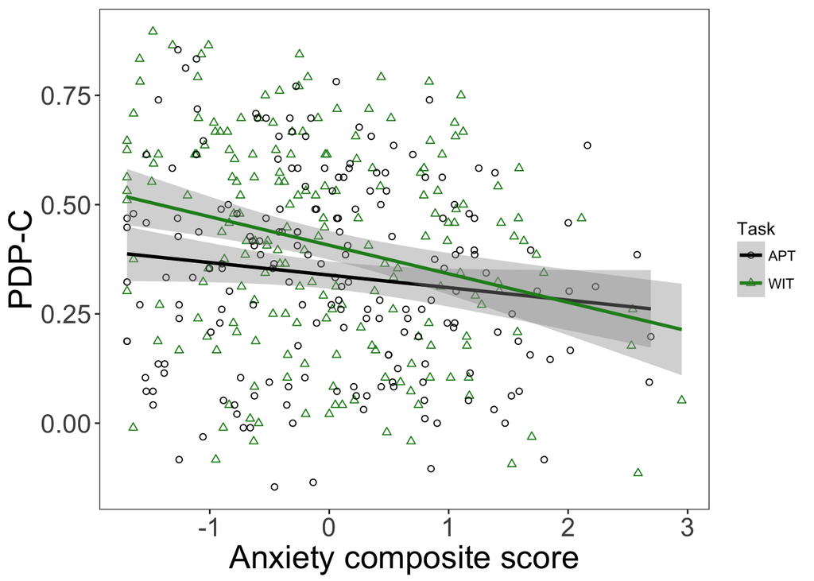

```
## Linear mixed model fit by REML
## t-tests use  Satterthwaite approximations to degrees of freedom ['lmerMod']
## Formula: MeanC ~ scale(Anx_composite) * Task + (1 | Subject)
##    Data: s2.wide
##
## REML criterion at convergence: -136.1
##
## Scaled residuals:
##      Min       1Q   Median       3Q      Max
## -2.09061 -0.49271  0.03496  0.55697  1.95890
##
## Random effects:
##  Groups   Name        Variance Std.Dev.
##  Subject  (Intercept) 0.03381  0.1839
##  Residual             0.01764  0.1328
## Number of obs: 386, groups:  Subject, 193
##
## Fixed effects:
##                               Estimate Std. Error        df t value Pr(>|t|)
## (Intercept)                    0.33925    0.01633 266.70000  20.769  < 2e-16 ***
## scale(Anx_composite)          -0.04235    0.01469 377.00000  -2.884  0.00415 **
## TaskWIT                        0.06763    0.01355 191.20000   4.991 1.35e-06 ***
## scale(Anx_composite):TaskWIT  -0.02641    0.01399 196.70000  -1.889  0.06043 .
## ---
## Signif. codes:  0 '***' 0.001 '**' 0.01 '*' 0.05 '.' 0.1 ' ' 1
##
## Correlation of Fixed Effects:
##             (Intr) sc(A_) TskWIT
## scl(Anx_cm) -0.031
## TaskWIT     -0.415  0.058
## sc(A_):TWIT  0.014 -0.455  0.002
```

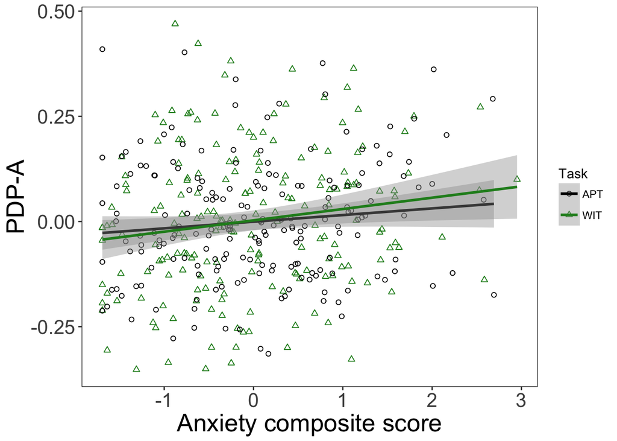

```
## Linear mixed model fit by REML
## t-tests use  Satterthwaite approximations to degrees of freedom ['lmerMod']
## Formula: AResid ~ scale(Anx_composite) * Task + (1 | Subject)
##    Data: s2.wide
##
## REML criterion at convergence: -331.2
##
## Scaled residuals:
##      Min       1Q   Median       3Q      Max
## -2.36687 -0.65794 -0.04769  0.60500  2.60405
##
## Random effects:
##  Groups   Name        Variance Std.Dev.
##  Subject  (Intercept) 0.005595 0.0748
##  Residual             0.018353 0.1355
## Number of obs: 386, groups:  Subject, 193
##
## Fixed effects:
##                                Estimate Std. Error         df t value Pr(>|t|)
## (Intercept)                  -4.377e-04  1.115e-02  3.622e+02  -0.039    0.969
## scale(Anx_composite)          1.421e-02  1.096e-02  3.786e+02   1.296    0.196
## TaskWIT                       3.064e-03  1.380e-02  1.912e+02   0.222    0.825
## scale(Anx_composite):TaskWIT  1.089e-02  1.403e-02  2.104e+02   0.776    0.438
##
## Correlation of Fixed Effects:
##             (Intr) sc(A_) TskWIT
## scl(Anx_cm) -0.033
## TaskWIT     -0.619  0.032
## sc(A_):TWIT  0.021 -0.624  0.001
```